# IODS course project

Bella Zhukova

# Introduction to Open Data Science - Course Project

# About the project

Hi, I’m Bella.

I’m on this course mostly for the ‘Data Science’ (statistics) part of it, as I already know how to use Git (if something I don’t know — Google will help) and used R from time to time.

GitHub repo: https://github.com/belochka/IODS-project

Diary: https://belochka.github.io/IODS-project/

```r
# This is a so-called "R chunk" where you can write R code.

date()
```

```
## [1] "Wed Nov  4 22:00:54 2020"
```

# 2. Regression and model validation

Let’s learn a bit about regression and model validation in this chapter. I am here to learn that as well, so, please, don’t consider it as a source of real knowledge.

Usually, it’s easier to understand a new topic on an example, therefore — here is one:

```r
students2014 <- read.table(file = 'data/learning2014.txt', sep=",")
```

This will read the data that was previously prepared such that we now can investigate it.

First, what is the data there?

```r
dim(students2014)
```

```
## [1] 166   7
```

This means that there are 166 lines and 7 columns. Ok, what’s the actual data afterall?

```r
str(students2014)
```

```
## 'data.frame':    166 obs. of  7 variables:
##  $ gender  : chr  "F" "M" "F" "M" ...
##  $ age     : int  53 55 49 53 49 38 50 37 37 42 ...
##  $ attitude: num  3.7 3.1 2.5 3.5 3.7 3.8 3.5 2.9 3.8 2.1 ...
##  $ deep    : num  3.58 2.92 3.5 3.5 3.67 ...
##  $ stra    : num  3.38 2.75 3.62 3.12 3.62 ...
##  $ surf    : num  2.58 3.17 2.25 2.25 2.83 ...
##  $ points  : int  25 12 24 10 22 21 21 31 24 26 ...
```

As far as I understand that is the answers to the questionnaire of students who took the “Introduction to social statistics course” (the original name in Finnish, but I still don’t know Finnish, so I’ll use the translation provided) in the autumn of 2014. `gender` and `age` are clearly understandable. `attitude` — some cumulative information about the attitude to learning of statistics, `deep` — how serious is the student about the learning process, they call it “deep approach”, `stra` — strategic approach (if a student have a plan for the week and studies, being able to make good use of the time, and so on), `surf` — surface approach (quite the opposite, something like: “I concentrate to learning just those bits of information I have to know to pass.”), `points` — exam points.

`attitude`, `deep`, `stra`, and `surf` can have values in the interval [1, 5], where, I suppose, `1` means “strongly disagree”, and ‘5’ means “strongly agree”. I’m not sure what was the maximum available result during the exam, but if to run

```r
summary(students2014)
```

```
##     gender               age           attitude          deep
##  Length:166         Min.   :17.00   Min.   :1.400   Min.   :1.583
##  Class :character   1st Qu.:21.00   1st Qu.:2.600   1st Qu.:3.333
##  Mode  :character   Median :22.00   Median :3.200   Median :3.667
##                     Mean   :25.51   Mean   :3.143   Mean   :3.680
##                     3rd Qu.:27.00   3rd Qu.:3.700   3rd Qu.:4.083
##                     Max.   :55.00   Max.   :5.000   Max.   :4.917
##       stra            surf           points
##  Min.   :1.250   Min.   :1.583   Min.   : 7.00
##  1st Qu.:2.625   1st Qu.:2.417   1st Qu.:19.00
##  Median :3.188   Median :2.833   Median :23.00
##  Mean   :3.121   Mean   :2.787   Mean   :22.72
##  3rd Qu.:3.625   3rd Qu.:3.167   3rd Qu.:27.75
##  Max.   :5.000   Max.   :4.333   Max.   :33.00
```

one can see, that in this dataset `points` have integer values in [7, 33].

As `summary()` doesn’t output a bit more interesting information about the `gender` column itself, let’s try

```r
table(students2014$gender)
```

```
##
##   F   M
## 110  56
```

There were 110 female students and 56 male students that finished the course.

Trying to grasp the data as a whole, let’s plot it:

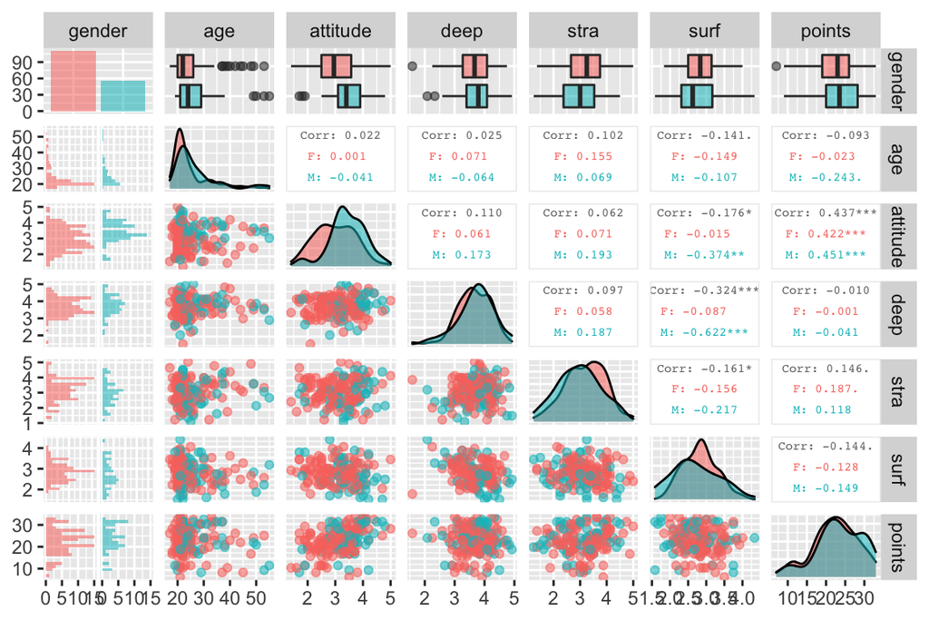

We know that there were more female students than male, therefore the pinkish is for females, and blueish — males. First column of horizontal histograms show how many females/males are of a certain age, have a certain attitute, and so forth. First row — boxplots — median, quartiles (median of lower and apper parts of the dataset), maximum, minimum and outliers. It shows that median global attitude toward statistics among females is lower than among males, males in general are less strategic then females in their approach for studies.

Statistics and distributions were in my life quite some time ago, so the rest might sound like a completely wrong thing to a more experienced (or with a deeper approach) person:

- `age` has either gamma or log-normal distribution
- `deep` — beta distribution
- `stra` looks like normal to me, ecpecially for males
- the rest — I don’t know.

The other thing to pay attention to is the symbol that explains the significance of the correlation (p-value):

`Signif. codes: 0 '***' 0.001 '**' 0.01 '*' 0.05 '.' 0.1 ' ' 1`

So one need to look closer to those pairs of columns that correspond to `***`. These are couples `surf -- deep` and `points -- attitude`.

What do points depend on (if on anything) in this dataset? To answer that question *multiple regression* can help. When there are more than one explanatory variables in the linear model, it is called multiple regression. Or some excerpt from [Wikipedia](https://en.wikipedia.org/wiki/Regression_analysis):

```
In statistical modeling, *regression analysis* is a set of statistical processes for estimating the relationships between a dependent variable and one or more independent variables. The most common form of regression analysis is *linear regression*, in which a researcher finds the line (or a more complex linear combination) that most closely fits the data according to a specific mathematical criterion.

Regression analysis is primarily used for two conceptually distinct purposes. First, regression analysis is widely used for *prediction* and *forecasting*, where its use has substantial overlap with the field of machine learning. Second, in some situations regression analysis can be used to *infer causal relationships* between the independent and dependent variables. Importantly, regressions by themselves only reveal relationships between a dependent variable and a collection of independent variables in a fixed dataset. To use regressions for prediction or to infer causal relationships, respectively, a researcher must carefully justify why existing relationships have predictive power for a new context or why a relationship between two variables has a causal interpretation.
```

Let’s choose the parameters with the biggest correlation regarding to `points`: `attitude`, `stra`, and `surf`.

```r
summary(lm(points ~ attitude + stra + surf, data = students2014))
```

```
##
## Call:
## lm(formula = points ~ attitude + stra + surf, data = students2014)
##
## Residuals:
##      Min       1Q   Median       3Q      Max
## -17.1550  -3.4346   0.5156   3.6401  10.8952
##
## Coefficients:
##             Estimate Std. Error t value Pr(>|t|)
## (Intercept)  11.0171     3.6837   2.991  0.00322 **
## attitude      3.3952     0.5741   5.913 1.93e-08 ***
## stra          0.8531     0.5416   1.575  0.11716
## surf         -0.5861     0.8014  -0.731  0.46563
## ---
## Signif. codes:  0 '***' 0.001 '**' 0.01 '*' 0.05 '.' 0.1 ' ' 1
##
## Residual standard error: 5.296 on 162 degrees of freedom
## Multiple R-squared:  0.2074, Adjusted R-squared:  0.1927
## F-statistic: 14.13 on 3 and 162 DF,  p-value: 3.156e-08
```

This summary shows that p-value < 0.05 only for attitude, what means that there is no statistically proved dependency between strategic approach and the points for the exam, or between surface approach and points. Therefore if to remove `stra` and `surf`:

```r
suggestedModel <- lm(points ~ attitude, data = students2014)
summary(suggestedModel)
```

```
##
## Call:
## lm(formula = points ~ attitude, data = students2014)
##
## Residuals:
##      Min       1Q   Median       3Q      Max
## -16.9763  -3.2119   0.4339   4.1534  10.6645
##
## Coefficients:
##             Estimate Std. Error t value Pr(>|t|)
## (Intercept)  11.6372     1.8303   6.358 1.95e-09 ***
## attitude      3.5255     0.5674   6.214 4.12e-09 ***
## ---
## Signif. codes:  0 '***' 0.001 '**' 0.01 '*' 0.05 '.' 0.1 ' ' 1
##
## Residual standard error: 5.32 on 164 degrees of freedom
## Multiple R-squared:  0.1906, Adjusted R-squared:  0.1856
## F-statistic: 38.61 on 1 and 164 DF,  p-value: 4.119e-09
```

the dependecy becomes even stronger (because p-value became smaller).

The formula of a line is $\alpha + \beta x$, the linear model has a formula $\alpha + \beta X + \varepsilon$, where $\alpha =$ intercept, $\beta$ — coefficient before predictors (in our case — only one — `attitude`), and $\varepsilon$ — an unobservable random variable, the error of the model.

*Residuals* are essentially the difference between the actual observed response values (`points` in our case) and the response values that the model predicted. When assessing how well the model fit the data, you should look for a symmetrical distribution across these points on the mean value zero (0). If the distribution of the residuals do not appear to be strongly symmetrical that means that the model predicts certain points that fall far away from the actual observed points.

The coefficient *t-value* is a measure of how many standard deviations our coefficient estimate is far away from 0. We want it to be far away from zero as this would indicate we could reject the null hypothesis — that is, we could declare a relationship between attitude and points exists. In our example, the t-statistic values are relatively far away from zero and are large relative to the standard error, which could indicate a relationship exists. In general, t-values are also used to compute p-values.

The *Pr(>t)* acronym found in the model output relates to the probability of observing any value equal or larger than t. A small p-value indicates that it is unlikely we will observe a relationship between the predictor (`attitude`) and response (`points`) variables due to chance. Typically, a p-value of 5% or less is a good cut-off point. In our model example, the p-values are very close to zero. Note the ‘signif. Codes’ associated to each estimate. Three stars (or asterisks) represent a highly significant p-value. Consequently, a small p-value for the intercept and the slope indicates that we can reject the null hypothesis, which allows us to conclude that there is a relationship between attitude and points.

The *R-squared* (R<sup>2</sup>) statistic provides a measure of how well the model is fitting the actual data. It takes the form of a proportion of variance. R<sup>2</sup> is a measure of the linear relationship between our predictor variable (`attitude`) and our response / target variable (`points`). It always lies between 0 and 1 (i.e.: a number near 0 represents a regression that does not explain the variance in the response variable well and a number close to 1 does explain the observed variance in the response variable). In our example, the R<sup>2</sup> we get is 0.1906. Or roughly 19% of the variance found in the response variable (`points`) can be explained by the predictor variable (`attitude`). It’s hard to define what level of R<sup>2</sup> is appropriate to claim the model fits well. Essentially, it will vary with the application and the domain studied.

A side note: In multiple regression settings, the R<sup>2</sup> will always increase as more variables are included in the model. That’s why the adjusted R<sup>2</sup> is the preferred measure as it adjusts for the number of variables considered.

*F-statistic* is a good indicator of whether there is a relationship between predictor and the response variables. The further the F-statistic is from 1 the better it is. However, how much larger the F-statistic needs to be depends on both the number of data points and the number of predictors. Generally, when the number of data points is large, an F-statistic that is only a little bit larger than 1 is already sufficient to reject the null hypothesis (H0 : There is no relationship between attitude and exam points). The reverse is true as if the number of data points is small, a large F-statistic is required to be able to ascertain that there may be a relationship between predictor and response variables. In our example the F-statistic is 38.61 which is relatively larger than 1 given the size of our data, I think. But I know almost nothing about statistics.

Ok, let’s look at the errors using diagnostic plots:

- Residuals vs Fitted values
- Normal QQ-plot
- Residuals vs Leverage

to explore the validity of the model assumptions.

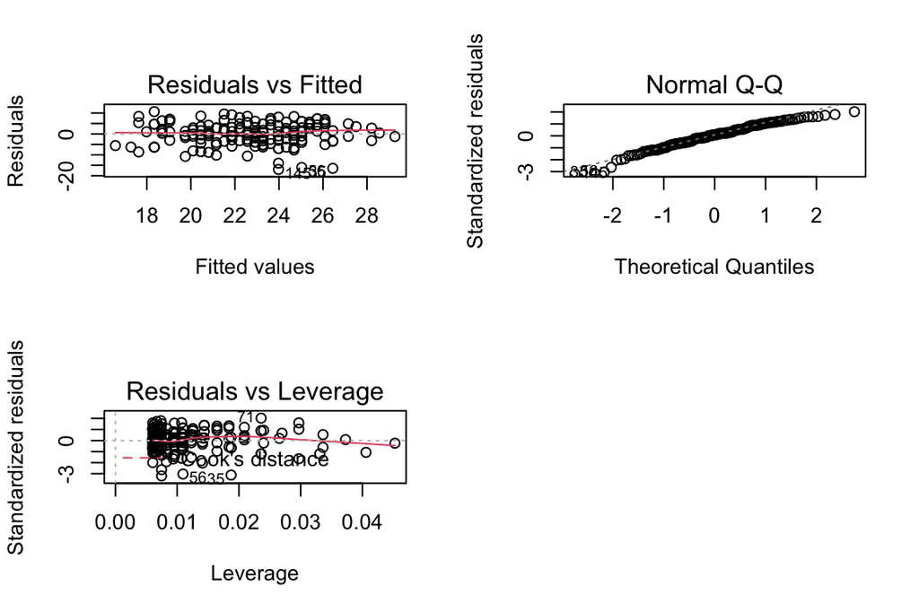

```r
par(mfrow = c(2,2))
plot(suggestedModel, which = c(1, 2, 5))
```

As far as I understood, in the linear model it is assumed that an unobservable random variable $\varepsilon$ is assumed to have an approximately normal distribution with the mean value = 0 and a constant variance, they are not correlated. The constant variance assumption implies that the size of the error should not depend on the explanatory variables. This can be explored with a scatter plot of residuals versus model predictions (*“Residuals vs Fitted values”*, `which = 1`). Any pattern in the scatter plot implies a problem with the assumption. In our example, nothing stands out much.

*QQ-plot* (`which = 2`) of the residuals — how well errors of the model fit the assumption of a normal distribution. When the point deviate from the line — the residuals are deviating from the behavior of normal distribution. So mostly, out linear approximation is actually predicting the exam `points` correctly.

*Leverage* measures how much impact a single observation has on model. *Residual vs Leverage* plot (`which = 5`) – to identify which observations have an unusually high impact. In this case — no single high leverage, therefore “unjustifiably” affecting the coefficients of the linear model.

Overall the actual data and the prediction together look like this:

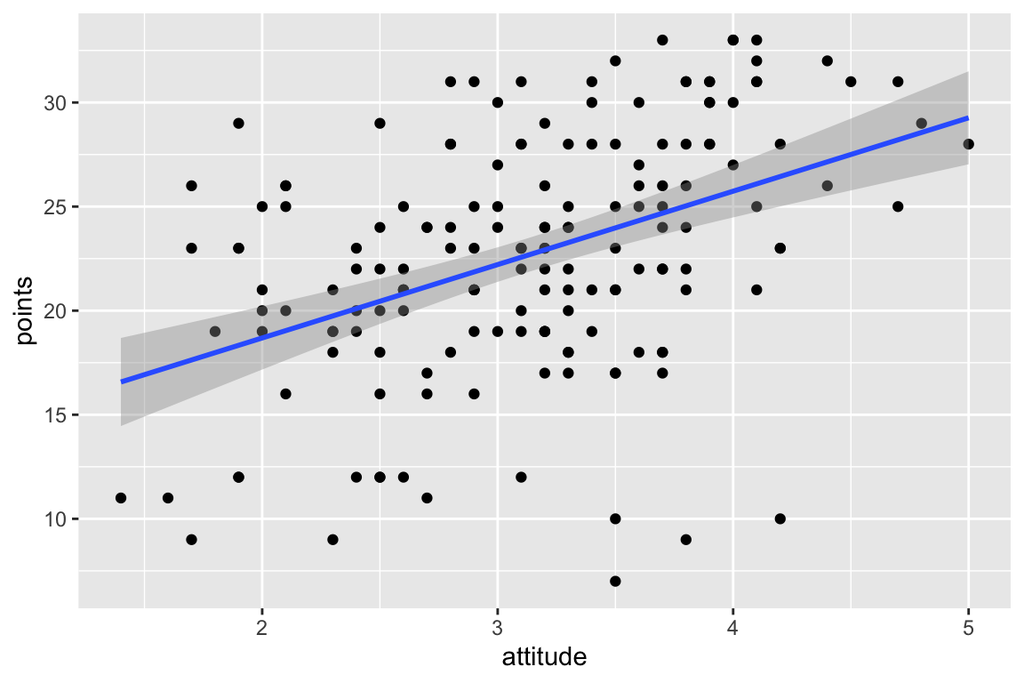

```r
qplot(attitude, points, data = students2014) + geom_smooth(method = "lm")
```

I’d say that based on the summary for the model and diagnostic plots, we have a linear model that almost perfectly explains the 19% of the data, and with the others the mistake is equal to the half of the value itself. Maybe an attitude is an important factor, but it’s not the only one affecting the result at the exam.

These factors might also be important — free time to spend on self-education at this course, tenancy to overcome all the blocks on the way in understanding the task itself, passion for writing (and skills), and experience in programming. Probably, some others as well.